# Strategic Competition Analysis: UAI vs Competitors

### Setup and Introduction

This strategic analysis focuses on the competitive landscape between UAI and its main competitors, examining school clusters, market share, and competitive positioning through key performance indicators.

**Key Focus Areas:** - 🎯 **Cluster-based analysis** showing school segments by career preferences - 📊 **Competitive comparison** between UAI, Competition 1, and Competition 2 - 🔥 **Heat maps** showing competitive intensity by region - 📈 **Lift metrics** measuring competitive advantage - 🎓 **Career-specific analysis** focusing only on shared programs

### 1. Data Loading and Strategic Preparation

We load the integrated dataset and focus on the **5 key UAI careers** that are shared with competitors: Business Engineering, Civil Engineering, Law, Psychology, and Journalism.

```r
# Load cleaned integrated data with clusters and coordinates
datos <- read_csv("datos_integrados_clean.csv")

# Data quality validation
cat("Dataset Overview:\n")
```

```
Dataset Overview:
```

```r
cat("Total schools:", nrow(datos), "\n")
```

```
Total schools: 2865
```

```r
cat("Schools with coordinates:", sum(!is.na(datos$LATITUD) & datos$LATITUD != ""), "\n")
```

```
Schools with coordinates: 2359
```

```r
cat("Geographic coverage:", round(sum(!is.na(datos$LATITUD) & datos$LATITUD != "") / nrow(datos) * 100, 2), "%\n")
```

```
Geographic coverage: 82.34 %
```

```r
# Strategic data preparation focusing on UAI's 5 key careers
datos_analisis <- datos %>%
  mutate(
    # Ensure key columns are numeric
    POSTULANTES_UAI = as.numeric(POSTULANTES_UAI),
    MATRICULADOS_UAI = as.numeric(MATRICULADOS_UAI),
    MATRI_COMPETENCIA_1 = as.numeric(MATRI_COMPETENCIA1),
    MATRI_COMPETENCIA_2 = as.numeric(MATRI_COMPETENCIA2),
    POST_COMPETENCIA_1 = as.numeric(POST_COMPETENCIA1),
    POST_COMPETENCIA_2 = as.numeric(POST_COMPETENCIA2),

    # Focus on FILTRADO variables (5 key UAI careers only)
    POST_UAI_KEY_CAREERS = as.numeric(POST_UAI_FILTRADO),
    MATRI_UAI_KEY_CAREERS = as.numeric(MATRI_UAI_FILTRADO),
    POST_COMP1_KEY_CAREERS = as.numeric(POST_COMPT1_FILTRADO),
    POST_COMP2_KEY_CAREERS = as.numeric(POST_COMPT2_FILTRADO),
    MATRI_COMP1_KEY_CAREERS = as.numeric(MATRI_COMPT1_FILTRADO),
    MATRI_COMP2_KEY_CAREERS = as.numeric(MATRI_COMPT2_FILTRADO),

    # Calculate key metrics for strategic analysis
    TASA_CONVERSION_UAI = if_else(POSTULANTES_UAI > 0, (MATRICULADOS_UAI / POSTULANTES_UAI) * 100, 0),

    # Market share calculations (percentage of total market)
    MARKET_SHARE_UAI_MATRI = if_else((MATRICULADOS_UAI + MATRI_COMPETENCIA_1 + MATRI_COMPETENCIA_2) > 0,
                                     (MATRICULADOS_UAI / (MATRICULADOS_UAI + MATRI_COMPETENCIA_1 + MATRI_COMPETENCIA_2)) * 100, 0),
    MARKET_SHARE_COMP1_MATRI = if_else((MATRICULADOS_UAI + MATRI_COMPETENCIA_1 + MATRI_COMPETENCIA_2) > 0,
                                       (MATRI_COMPETENCIA_1 / (MATRICULADOS_UAI + MATRI_COMPETENCIA_1 + MATRI_COMPETENCIA_2)) * 100, 0),
    MARKET_SHARE_COMP2_MATRI = if_else((MATRICULADOS_UAI + MATRI_COMPETENCIA_1 + MATRI_COMPETENCIA_2) > 0,
                                       (MATRI_COMPETENCIA_2 / (MATRICULADOS_UAI + MATRI_COMPETENCIA_1 + MATRI_COMPETENCIA_2)) * 100, 0),

    # LIFT METRIC: Competitive advantage ratio
    LIFT_COMP1_vs_UAI = if_else(MARKET_SHARE_UAI_MATRI > 0, MARKET_SHARE_COMP1_MATRI / MARKET_SHARE_UAI_MATRI, 0),
    LIFT_COMP2_vs_UAI = if_else(MARKET_SHARE_UAI_MATRI > 0, MARKET_SHARE_COMP2_MATRI / MARKET_SHARE_UAI_MATRI, 0)
  ) %>%
  # Assign cluster names
  rename(CLUSTER_ID = "cluster_carreras_general") %>%
  filter(CLUSTER_ID %in% 1:6) %>%
  mutate(
    CLUSTER_NOMBRE = case_when(
      CLUSTER_ID == 1 ~ "Interest in Civil Engineering",
      CLUSTER_ID == 2 ~ "Oriented to Law",
      CLUSTER_ID == 3 ~ "Diverse Interests",
      CLUSTER_ID == 4 ~ "Communications Profile",
      CLUSTER_ID == 5 ~ "Business Engineering Focus",
      CLUSTER_ID == 6 ~ "Psychology Focus"
    ),
    CLUSTER_NOMBRE = as.factor(CLUSTER_NOMBRE)
  )

# Filter to schools with activity in key careers
datos_analisis <- datos_analisis %>%
  filter(POST_UAI_KEY_CAREERS > 0 | MATRI_UAI_KEY_CAREERS > 0 |
         POST_COMP1_KEY_CAREERS > 0 | MATRI_COMP1_KEY_CAREERS > 0 |
         POST_COMP2_KEY_CAREERS > 0 | MATRI_COMP2_KEY_CAREERS > 0)

cat("Schools with activity in key careers:", nrow(datos_analisis), "\n")
```

```
Schools with activity in key careers: 2486
```

```r
cat("Cluster distribution:\n")
```

```
Cluster distribution:
```

```r
print(table(datos_analisis$CLUSTER_NOMBRE))
```

```
   Business Engineering Focus        Communications Profile
                           96                           247
            Diverse Interests Interest in Civil Engineering
                         1067                           185
              Oriented to Law              Psychology Focus
                          547                           344
```

### 2. Strategic Performance Summary by Cluster

This table shows the competitive performance metrics for each school cluster, focusing on market share and competitive positioning.

```r
resumen_segmentos <- datos_analisis %>%
  group_by(CLUSTER_NOMBRE) %>%
  summarise(
    N_COLEGIOS = n(),
    PROMEDIO_PTJE = mean(PTJE_PROM, na.rm = TRUE),

    # Key career metrics
    TOTAL_POST_UAI = sum(POST_UAI_KEY_CAREERS, na.rm = TRUE),
    TOTAL_MATRI_UAI = sum(MATRI_UAI_KEY_CAREERS, na.rm = TRUE),
    TOTAL_MATRI_COMP1 = sum(MATRI_COMP1_KEY_CAREERS, na.rm = TRUE),
    TOTAL_MATRI_COMP2 = sum(MATRI_COMP2_KEY_CAREERS, na.rm = TRUE),

    # Market share averages
    PROMEDIO_MARKET_SHARE_UAI = mean(MARKET_SHARE_UAI_MATRI, na.rm = TRUE),
    PROMEDIO_MARKET_SHARE_COMP1 = mean(MARKET_SHARE_COMP1_MATRI, na.rm = TRUE),
    PROMEDIO_MARKET_SHARE_COMP2 = mean(MARKET_SHARE_COMP2_MATRI, na.rm = TRUE),

    # Lift metrics
    PROMEDIO_LIFT_COMP1 = mean(LIFT_COMP1_vs_UAI, na.rm = TRUE),
    PROMEDIO_LIFT_COMP2 = mean(LIFT_COMP2_vs_UAI, na.rm = TRUE)
  ) %>%
  arrange(desc(PROMEDIO_MARKET_SHARE_UAI))

datatable(resumen_segmentos,
          caption = "Strategic Performance by School Cluster",
          colnames = c('Cluster', 'Schools', 'Avg Score', 'UAI Apps', 'UAI Enrolled', 'Comp1 Enrolled', 'Comp2 Enrolled', 'UAI Market Share (%)', 'Comp1 Market Share (%)', 'Comp2 Market Share (%)', 'Comp1 Lift', 'Comp2 Lift'))
```

|  | Cluster | Schools | Avg Score | UAI Apps | UAI Enrolled | Comp1 Enrolled | Comp2 Enrolled | UAI Market Share (%) | Comp1 Market Share (%) | Comp2 Market Share (%) | Comp1 Lift | Comp2 Lift |
| --- | --- | --- | --- | --- | --- | --- | --- | --- | --- | --- | --- | --- |
| 1 | Oriented to Law | 547 | 571878133840691.4 | 1594 | 172 | 1980 | 414 | 7.88415297362069 | 66.36844335907536 | 23.00517331995478 | 4.967381558527466 | 1.769506102276038 |
| 2 | Business Engineering Focus | 96 | 522892225431714.4 | 30 | 9 | 130 | 1 | 4.46475129019886 | 63.67613132486223 | 16.23411738493891 | 0.4873263888888889 | 0.2649305555555556 |
| 3 | Communications Profile | 247 | 492554948294166.4 | 247 | 15 | 413 | 41 | 3.236575191092772 | 77.03847036107943 | 11.62778845592496 | 2.008232118758435 | 0.4068151147098515 |
| 4 | Interest in Civil Engineering | 185 | 506102000011898.4 | 122 | 14 | 784 | 7 | 1.813329479270152 | 71.3788870381689 | 17.07805375283123 | 1.661261261261261 | 0.8344701844701845 |
| 5 | Psychology Focus | 344 | 524508563564537.1 | 115 | 7 | 437 | 11 | 1.706844797608218 | 58.70736401985986 | 16.91137257788076 | 0.4774709302325582 | 0.2708333333333333 |
| 6 | Diverse Interests | 1067 | 489901572763211.9 | 492 | 19 | 1143 | 55 | 1.302431174929178 | 74.06038957445077 | 13.0158109282208 | 0.9687597625741956 | 0.1789284598562949 |

### 3. Strategic Geographic Analysis

#### 3.1. School Clusters Map (Colors by Cluster)

This map shows schools colored by their **career preference clusters**, providing insight into geographic distribution of different academic profiles.

```r
paleta_clusters <- colorFactor(palette = "Set1", domain = datos_analisis$CLUSTER_NOMBRE)

leaflet(data = datos_analisis %>% filter(!is.na(LATITUD) & !is.na(LONGITUD))) %>%
  addProviderTiles(providers$CartoDB.Positron) %>%
  addCircleMarkers(
    ~LONGITUD, ~LATITUD,
    color = ~paleta_clusters(CLUSTER_NOMBRE),
    stroke = FALSE, fillOpacity = 0.8, radius = 6,
    popup = ~paste("<div style='font-size: 12px;'>",
                   "<b>School:</b>", NOM_RBD, "<br>",
                   "<b>Cluster:</b>", CLUSTER_NOMBRE, "<br>",
                   "<b>Average Score:</b>", round(PTJE_PROM, 1), "<br><br>",
                   "<b>Key Career Activity:</b><br>",
                   "UAI Apps: ", POST_UAI_KEY_CAREERS, "<br>",
                   "UAI Enrolled: ", MATRI_UAI_KEY_CAREERS, "<br>",
                   "Comp1 Enrolled: ", MATRI_COMP1_KEY_CAREERS, "<br>",
                   "Comp2 Enrolled: ", MATRI_COMP2_KEY_CAREERS, "<br>",
                   "</div>")
  ) %>%
  addLegend("bottomright", pal = paleta_clusters, values = ~CLUSTER_NOMBRE,
            title = "School Clusters", opacity = 1)
```

[interactive chart not shown]

#### 3.2. Competitive Comparison Map: Matriculations vs Postulations

This strategic map compares UAI’s performance against both competitors in terms of **matriculations** and **postulations** for the 5 key careers.

```r
# Prepare data for comparison map
datos_comparison <- datos_analisis %>%
  filter(!is.na(LATITUD) & !is.na(LONGITUD)) %>%
  mutate(
    # Determine which institution has highest market share
    MAX_MARKET_SHARE = pmax(MARKET_SHARE_UAI_MATRI, MARKET_SHARE_COMP1_MATRI, MARKET_SHARE_COMP2_MATRI),
    WINNER_MATRI = case_when(
      MARKET_SHARE_UAI_MATRI == MAX_MARKET_SHARE & MARKET_SHARE_UAI_MATRI > 0 ~ "UAI Leads",
      MARKET_SHARE_COMP1_MATRI == MAX_MARKET_SHARE & MARKET_SHARE_COMP1_MATRI > 0 ~ "Competition 1 Leads",
      MARKET_SHARE_COMP2_MATRI == MAX_MARKET_SHARE & MARKET_SHARE_COMP2_MATRI > 0 ~ "Competition 2 Leads",
      TRUE ~ "No Clear Winner"
    ),
    # Size based on total activity in key careers
    TOTAL_ACTIVITY = POST_UAI_KEY_CAREERS + MATRI_UAI_KEY_CAREERS +
                     POST_COMP1_KEY_CAREERS + MATRI_COMP1_KEY_CAREERS +
                     POST_COMP2_KEY_CAREERS + MATRI_COMP2_KEY_CAREERS
  ) %>%
  filter(TOTAL_ACTIVITY > 0)

# Color palette for winners
paleta_winners <- colorFactor(
  palette = c("#2ecc71", "#f39c12", "#e74c3c", "#95a5a6"),  # Green, Orange, Red, Gray
  domain = c("UAI Leads", "Competition 1 Leads", "Competition 2 Leads", "No Clear Winner")
)

leaflet(data = datos_comparison) %>%
  addProviderTiles(providers$CartoDB.Positron) %>%
  addCircleMarkers(
    ~LONGITUD, ~LATITUD,
    color = ~paleta_winners(WINNER_MATRI),
    stroke = TRUE, weight = 1, fillOpacity = 0.7,
    radius = ~sqrt(TOTAL_ACTIVITY) * 1.5 + 3,
    popup = ~paste("<div style='font-size: 12px;'>",
                   "<b style='font-size: 14px;'>", NOM_RBD, "</b><br>",
                   "<b>Cluster:</b>", CLUSTER_NOMBRE, "<br><br>",

                   "<b style='color: #3498db;'>🏆 MARKET SHARE LEADER:</b><br>",
                   "<b>", WINNER_MATRI, "</b><br><br>",

                   "<b style='color: #27ae60;'>📊 UAI PERFORMANCE:</b><br>",
                   "Market Share: ", sprintf("%.1f%%", MARKET_SHARE_UAI_MATRI), "<br>",
                   "Applications: ", POST_UAI_KEY_CAREERS, "<br>",
                   "Enrollments: ", MATRI_UAI_KEY_CAREERS, "<br><br>",

                   "<b style='color: #f39c12;'>📈 COMPETITION 1:</b><br>",
                   "Market Share: ", sprintf("%.1f%%", MARKET_SHARE_COMP1_MATRI), "<br>",
                   "Enrollments: ", MATRI_COMP1_KEY_CAREERS, "<br><br>",

                   "<b style='color: #e74c3c;'>📈 COMPETITION 2:</b><br>",
                   "Market Share: ", sprintf("%.1f%%", MARKET_SHARE_COMP2_MATRI), "<br>",
                   "Enrollments: ", MATRI_COMP2_KEY_CAREERS, "<br>",
                   "</div>")
  ) %>%
  addLegend("bottomright", pal = paleta_winners, values = ~WINNER_MATRI,
            title = "Market Share Leader", opacity = 1)
```

[interactive chart not shown]

#### 3.3. Geographic Heat Map: Competition 2 vs UAI

This geographic heat map shows the competitive intensity between **Competition 2 and UAI** across Chile, with regions colored by their competitive position. This provides an intuitive geographic view of where UAI has advantages versus where Competition 2 dominates.

```r
# Create geographic heat map data for Competition 2 vs UAI
geo_heatmap_data <- datos_analisis %>%
  filter(!is.na(REGION_RBD)) %>%
  group_by(REGION_RBD) %>%
  summarise(
    TOTAL_UAI_MATRI = sum(MATRI_UAI_KEY_CAREERS, na.rm = TRUE),
    TOTAL_COMP2_MATRI = sum(MATRI_COMP2_KEY_CAREERS, na.rm = TRUE),
    TOTAL_MARKET = TOTAL_UAI_MATRI + TOTAL_COMP2_MATRI,
    SCHOOLS_COUNT = n(),
    .groups = 'drop'
  ) %>%
  filter(TOTAL_MARKET > 10) %>%  # Filter for meaningful data
  mutate(
    UAI_MARKET_SHARE = (TOTAL_UAI_MATRI / TOTAL_MARKET) * 100,
    COMP2_MARKET_SHARE = (TOTAL_COMP2_MATRI / TOTAL_MARKET) * 100,
    LIFT_COMP2 = if_else(UAI_MARKET_SHARE > 5, COMP2_MARKET_SHARE / UAI_MARKET_SHARE, 0),
    # Cap extreme values for better visualization
    LIFT_COMP2_CAPPED = pmin(LIFT_COMP2, 3),
    # Create competitive intensity categories
    COMPETITIVE_INTENSITY = case_when(
      LIFT_COMP2_CAPPED < 0.5 ~ "UAI Strong Advantage",
      LIFT_COMP2_CAPPED < 1 ~ "UAI Moderate Advantage",
      LIFT_COMP2_CAPPED < 1.5 ~ "Competition 2 Moderate Advantage",
      LIFT_COMP2_CAPPED < 2.5 ~ "Competition 2 Strong Advantage",
      TRUE ~ "Competition 2 Dominant"
    )
  )

# Define region centroids for mapping (approximate coordinates)
region_centroids <- data.frame(
  REGION_RBD = 1:16,
  REGION_NOMBRE = c("Tarapacá", "Antofagasta", "Atacama", "Coquimbo", "Valparaíso",
                    "O'Higgins", "Maule", "Biobío", "Araucanía", "Los Lagos",
                    "Aysén", "Magallanes", "Metropolitana", "Los Ríos", "Arica y Parinacota", "Ñuble"),
  LAT_CENTER = c(-20.2, -23.6, -27.4, -30.0, -33.0, -34.2, -35.4, -36.8, -38.7, -41.5,
                  -45.9, -53.2, -33.4, -39.8, -18.5, -36.6),
  LON_CENTER = c(-70.1, -69.3, -70.3, -71.3, -71.6, -70.7, -71.6, -73.0, -72.6, -72.3,
                 -72.1, -70.9, -70.6, -73.2, -69.9, -72.1)
)

# Merge with centroids
geo_heatmap_with_coords <- geo_heatmap_data %>%
  left_join(region_centroids, by = "REGION_RBD")

# Create the geographic heat map using leaflet
paleta_competition <- colorFactor(
  palette = c("#2ecc71", "#27ae60", "#f39c12", "#e67e22", "#e74c3c"),  # Green to Red
  domain = c("UAI Strong Advantage", "UAI Moderate Advantage", "Competition 2 Moderate Advantage",
             "Competition 2 Strong Advantage", "Competition 2 Dominant")
)

# Calculate radius based on total market activity
geo_heatmap_with_coords <- geo_heatmap_with_coords %>%
  mutate(
    RADIUS = sqrt(TOTAL_MARKET) * 3 + 10  # Scale radius based on market size
  )

leaflet(data = geo_heatmap_with_coords %>% filter(!is.na(LAT_CENTER) & !is.na(LON_CENTER))) %>%
  addProviderTiles(providers$CartoDB.Positron) %>%
  addCircleMarkers(
    ~LON_CENTER, ~LAT_CENTER,
    color = ~paleta_competition(COMPETITIVE_INTENSITY),
    stroke = TRUE, weight = 2, fillOpacity = 0.8,
    radius = ~RADIUS,
    popup = ~paste(
      "<div style='font-size: 12px;'>",
      "<b style='font-size: 16px;'>", REGION_NOMBRE, "</b><br>",
      "<b style='color: #3498db;'>🏆 COMPETITIVE POSITION:</b><br>",
      "<b>", COMPETITIVE_INTENSITY, "</b><br><br>",

      "<b style='color: #27ae60;'>📊 UAI PERFORMANCE:</b><br>",
      "Enrolled: ", TOTAL_UAI_MATRI, " students<br>",
      "Market Share: ", sprintf("%.1f%%", UAI_MARKET_SHARE), "<br><br>",

      "<b style='color: #e74c3c;'>📈 COMPETITION 2:</b><br>",
      "Enrolled: ", TOTAL_COMP2_MATRI, " students<br>",
      "Market Share: ", sprintf("%.1f%%", COMP2_MARKET_SHARE), "<br><br>",

      "<b style='color: #f39c12;'>⚖️ LIFT RATIO:</b> ", sprintf("%.2f", LIFT_COMP2), "<br>",
      "<b>Total Market:</b> ", TOTAL_MARKET, " students<br>",
      "<b>Schools:</b> ", SCHOOLS_COUNT,
      "</div>"
    )
  ) %>%
  addLegend(
    "bottomright",
    pal = paleta_competition,
    values = ~COMPETITIVE_INTENSITY,
    title = "Competition 2 vs UAI<br>Competitive Position",
    opacity = 1
  ) %>%
  setView(lng = -71.5, lat = -35.0, zoom = 5)  # Center on Chile
```

[interactive chart not shown]

#### 3.4. School-Level Geographic Heat Map

This map shows individual schools colored by their competitive position, providing granular insight into local competitive dynamics:

```r
# Create school-level competitive data
school_competitive_data <- datos_analisis %>%
  filter(!is.na(LATITUD) & !is.na(LONGITUD)) %>%
  mutate(
    # Calculate school-level lift metrics
    SCHOOL_LIFT_COMP2 = if_else(MARKET_SHARE_UAI_MATRI > 0,
                                MARKET_SHARE_COMP2_MATRI / MARKET_SHARE_UAI_MATRI, 0),
    SCHOOL_LIFT_COMP2_CAPPED = pmin(SCHOOL_LIFT_COMP2, 3),
    # Create competitive categories
    SCHOOL_COMPETITIVE_POSITION = case_when(
      SCHOOL_LIFT_COMP2_CAPPED < 0.5 ~ "UAI Strong Advantage",
      SCHOOL_LIFT_COMP2_CAPPED < 1 ~ "UAI Moderate Advantage",
      SCHOOL_LIFT_COMP2_CAPPED < 1.5 ~ "Competition 2 Moderate Advantage",
      SCHOOL_LIFT_COMP2_CAPPED < 2.5 ~ "Competition 2 Strong Advantage",
      TRUE ~ "Competition 2 Dominant"
    ),
    # Calculate total activity for sizing
    TOTAL_SCHOOL_ACTIVITY = MATRI_UAI_KEY_CAREERS + MATRI_COMP1_KEY_CAREERS + MATRI_COMP2_KEY_CAREERS
  ) %>%
  filter(TOTAL_SCHOOL_ACTIVITY > 0)  # Only schools with activity

# Create color palette for schools
paleta_schools <- colorFactor(
  palette = c("#2ecc71", "#27ae60", "#f39c12", "#e67e22", "#e74c3c"),
  domain = c("UAI Strong Advantage", "UAI Moderate Advantage", "Competition 2 Moderate Advantage",
             "Competition 2 Strong Advantage", "Competition 2 Dominant")
)

leaflet(data = school_competitive_data) %>%
  addProviderTiles(providers$CartoDB.Positron) %>%
  addCircleMarkers(
    ~LONGITUD, ~LATITUD,
    color = ~paleta_schools(SCHOOL_COMPETITIVE_POSITION),
    stroke = FALSE, fillOpacity = 0.7,
    radius = ~sqrt(TOTAL_SCHOOL_ACTIVITY) * 1.5 + 3,
    popup = ~paste(
      "<div style='font-size: 11px;'>",
      "<b style='font-size: 14px;'>", NOM_RBD, "</b><br>",
      "<b>Cluster:</b>", CLUSTER_NOMBRE, "<br><br>",

      "<b style='color: #3498db;'>🏆 COMPETITIVE POSITION:</b><br>",
      "<b>", SCHOOL_COMPETITIVE_POSITION, "</b><br><br>",

      "<b style='color: #27ae60;'>📊 UAI:</b> ", MATRI_UAI_KEY_CAREERS, " enrolled<br>",
      "<b style='color: #f39c12;'>📈 COMP1:</b> ", MATRI_COMP1_KEY_CAREERS, " enrolled<br>",
      "<b style='color: #e74c3c;'>📈 COMP2:</b> ", MATRI_COMP2_KEY_CAREERS, " enrolled<br><br>",

      "<b style='color: #f39c12;'>⚖️ LIFT RATIO:</b> ", sprintf("%.2f", SCHOOL_LIFT_COMP2), "<br>",
      "<b>Average Score:</b> ", round(PTJE_PROM, 1),
      "</div>"
    )
  ) %>%
  addLegend(
    "bottomright",
    pal = paleta_schools,
    values = ~SCHOOL_COMPETITIVE_POSITION,
    title = "School Competitive Position<br>Competition 2 vs UAI",
    opacity = 1
  ) %>%
  setView(lng = -71.5, lat = -35.0, zoom = 5)
```

[interactive chart not shown]

#### 3.5. Alternative: Simple Competition 2 vs UAI Analysis

For easier interpretation, here’s a simpler view focusing on the most significant competitive relationships:

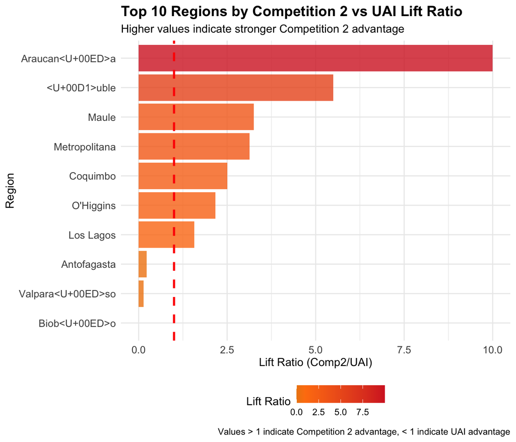

```r
# Define region names for labeling
region_names <- data.frame(
  REGION_RBD = 1:16,
  REGION_NOMBRE = c("Tarapacá", "Antofagasta", "Atacama", "Coquimbo", "Valparaíso",
                    "O'Higgins", "Maule", "Biobío", "Araucanía", "Los Lagos",
                    "Aysén", "Magallanes", "Metropolitana", "Los Ríos", "Arica y Parinacota", "Ñuble")
)

# Create a simpler analysis focusing on top competitive regions
top_competitive_regions <- geo_heatmap_data %>%
  filter(TOTAL_MARKET > 10) %>%  # Only regions with meaningful activity
  select(REGION_RBD, LIFT_COMP2, TOTAL_MARKET) %>%
  left_join(region_names, by = "REGION_RBD") %>%
  arrange(desc(LIFT_COMP2)) %>%
  head(10)  # Top 10 most competitive regions

# Create a bar chart for better readability
ggplot(top_competitive_regions, aes(x = reorder(REGION_NOMBRE, LIFT_COMP2), y = LIFT_COMP2)) +
  geom_col(aes(fill = LIFT_COMP2), alpha = 0.8) +
  geom_hline(yintercept = 1, linetype = "dashed", color = "red", size = 1) +
  scale_fill_gradient2(low = "#2ca02c", mid = "#ff7f0e", high = "#d62728",
                       midpoint = 1, name = "Lift Ratio") +
  coord_flip() +
  labs(
    title = "Top 10 Regions by Competition 2 vs UAI Lift Ratio",
    subtitle = "Higher values indicate stronger Competition 2 advantage",
    x = "Region",
    y = "Lift Ratio (Comp2/UAI)",
    caption = "Values > 1 indicate Competition 2 advantage, < 1 indicate UAI advantage"
  ) +
  theme_minimal() +
  theme(
    legend.position = "bottom",
    plot.title = element_text(size = 14, face = "bold"),
    axis.text = element_text(size = 10)
  ) +
  annotate("text", x = Inf, y = 1, label = "Equal Performance",
           hjust = 1.1, vjust = -0.5, color = "red", fontface = "bold")
```

**Heat Map Interpretation:** - **Green (0-1)**: UAI has advantage over Competition 2 - **Orange (1-2)**: Competition 2 has moderate advantage - **Red (2+)**: Competition 2 has strong advantage over UAI - Values represent the ratio: Competition 2 Market Share / UAI Market Share

### 4. Lift Metrics Analysis

The lift metric measures competitive advantage by calculating the ratio of competitor market share to UAI market share. A lift > 1 indicates the competitor has advantage, while lift < 1 indicates UAI advantage.

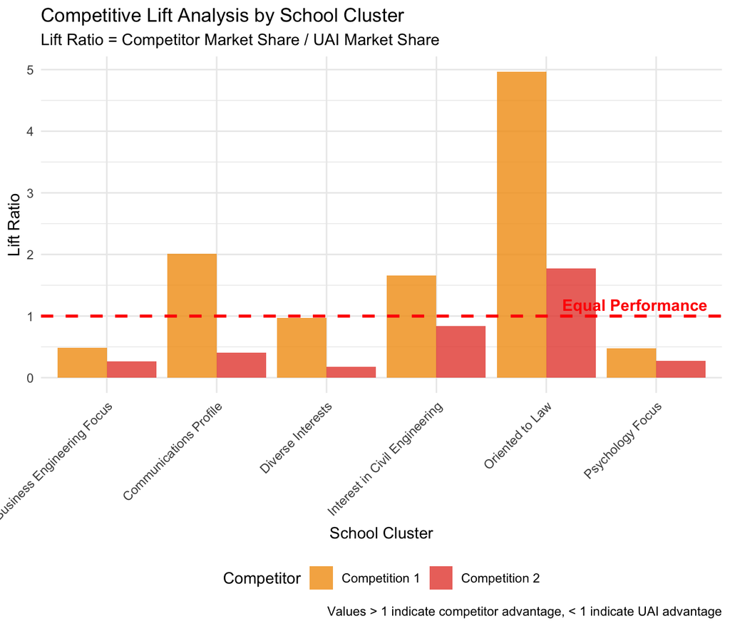

```r
# Create lift metrics summary by cluster
lift_summary <- datos_analisis %>%
  group_by(CLUSTER_NOMBRE) %>%
  summarise(
    Schools = n(),
    Avg_Lift_Comp1 = mean(LIFT_COMP1_vs_UAI, na.rm = TRUE),
    Avg_Lift_Comp2 = mean(LIFT_COMP2_vs_UAI, na.rm = TRUE),
    UAI_Advantage_Comp1 = sum(LIFT_COMP1_vs_UAI < 1, na.rm = TRUE),
    UAI_Advantage_Comp2 = sum(LIFT_COMP2_vs_UAI < 1, na.rm = TRUE),
    .groups = 'drop'
  ) %>%
  mutate(
    Comp1_Advantage_Pct = (Schools - UAI_Advantage_Comp1) / Schools * 100,
    Comp2_Advantage_Pct = (Schools - UAI_Advantage_Comp2) / Schools * 100
  )

# Create lift comparison chart
lift_chart_data <- lift_summary %>%
  select(CLUSTER_NOMBRE, Avg_Lift_Comp1, Avg_Lift_Comp2) %>%
  pivot_longer(cols = c(Avg_Lift_Comp1, Avg_Lift_Comp2),
               names_to = "Competitor", values_to = "Lift_Ratio") %>%
  mutate(
    Competitor = case_when(
      Competitor == "Avg_Lift_Comp1" ~ "Competition 1",
      Competitor == "Avg_Lift_Comp2" ~ "Competition 2"
    ),
    Advantage_Type = case_when(
      Lift_Ratio < 1 ~ "UAI Advantage",
      Lift_Ratio >= 1 & Lift_Ratio < 2 ~ "Moderate Competitor Advantage",
      Lift_Ratio >= 2 ~ "Strong Competitor Advantage"
    )
  )

ggplot(lift_chart_data, aes(x = CLUSTER_NOMBRE, y = Lift_Ratio, fill = Competitor)) +
  geom_col(position = "dodge", alpha = 0.8) +
  geom_hline(yintercept = 1, linetype = "dashed", color = "red", size = 1) +
  scale_fill_manual(values = c("#f39c12", "#e74c3c")) +
  labs(
    title = "Competitive Lift Analysis by School Cluster",
    subtitle = "Lift Ratio = Competitor Market Share / UAI Market Share",
    x = "School Cluster",
    y = "Lift Ratio",
    fill = "Competitor",
    caption = "Values > 1 indicate competitor advantage, < 1 indicate UAI advantage"
  ) +
  theme_minimal() +
  theme(
    axis.text.x = element_text(angle = 45, hjust = 1),
    legend.position = "bottom"
  ) +
  annotate("text", x = Inf, y = 1, label = "Equal Performance",
           hjust = 1.1, vjust = -0.5, color = "red", fontface = "bold")
```

#### 4.1. Lift Metrics Summary Table

```r
lift_summary %>%
  select(CLUSTER_NOMBRE, Schools, Avg_Lift_Comp1, Avg_Lift_Comp2,
         Comp1_Advantage_Pct, Comp2_Advantage_Pct) %>%
  mutate(
    Avg_Lift_Comp1 = round(Avg_Lift_Comp1, 2),
    Avg_Lift_Comp2 = round(Avg_Lift_Comp2, 2),
    Comp1_Advantage_Pct = round(Comp1_Advantage_Pct, 1),
    Comp2_Advantage_Pct = round(Comp2_Advantage_Pct, 1)
  ) %>%
  datatable(
    caption = "Lift Metrics Summary by Cluster",
    colnames = c('Cluster', 'Schools', 'Avg Lift Comp1', 'Avg Lift Comp2',
                 'Comp1 Advantage %', 'Comp2 Advantage %'),
    options = list(pageLength = 10)
  )
```

|  | Cluster | Schools | Avg Lift Comp1 | Avg Lift Comp2 | Comp1 Advantage % | Comp2 Advantage % |
| --- | --- | --- | --- | --- | --- | --- |
| 1 | Business Engineering Focus | 96 | 0.49 | 0.26 | 12.5 | 10.4 |
| 2 | Communications Profile | 247 | 2.01 | 0.41 | 15.8 | 11.7 |
| 3 | Diverse Interests | 1067 | 0.97 | 0.18 | 7.8 | 5 |
| 4 | Interest in Civil Engineering | 185 | 1.66 | 0.83 | 14.6 | 12.4 |
| 5 | Oriented to Law | 547 | 4.97 | 1.77 | 51.4 | 41.5 |
| 6 | Psychology Focus | 344 | 0.48 | 0.27 | 7.6 | 4.1 |

### 5. Key Strategic Insights

Based on the analysis of school clusters, competitive positioning, and lift metrics, here are the key strategic insights:

#### 5.1. Cluster Performance Summary

```r
# Create strategic insights summary
insights_summary <- datos_analisis %>%
  group_by(CLUSTER_NOMBRE) %>%
  summarise(
    Total_Schools = n(),
    Avg_Market_Share_UAI = mean(MARKET_SHARE_UAI_MATRI, na.rm = TRUE),
    Avg_Market_Share_Comp1 = mean(MARKET_SHARE_COMP1_MATRI, na.rm = TRUE),
    Avg_Market_Share_Comp2 = mean(MARKET_SHARE_COMP2_MATRI, na.rm = TRUE),
    UAI_Wins = sum(MARKET_SHARE_UAI_MATRI > pmax(MARKET_SHARE_COMP1_MATRI, MARKET_SHARE_COMP2_MATRI), na.rm = TRUE),
    Comp1_Wins = sum(MARKET_SHARE_COMP1_MATRI > pmax(MARKET_SHARE_UAI_MATRI, MARKET_SHARE_COMP2_MATRI), na.rm = TRUE),
    Comp2_Wins = sum(MARKET_SHARE_COMP2_MATRI > pmax(MARKET_SHARE_UAI_MATRI, MARKET_SHARE_COMP1_MATRI), na.rm = TRUE),
    .groups = 'drop'
  ) %>%
  mutate(
    UAI_Win_Rate = round(UAI_Wins / Total_Schools * 100, 1),
    Comp1_Win_Rate = round(Comp1_Wins / Total_Schools * 100, 1),
    Comp2_Win_Rate = round(Comp2_Wins / Total_Schools * 100, 1),
    Avg_Market_Share_UAI = round(Avg_Market_Share_UAI, 1),
    Avg_Market_Share_Comp1 = round(Avg_Market_Share_Comp1, 1),
    Avg_Market_Share_Comp2 = round(Avg_Market_Share_Comp2, 1)
  )

datatable(
  insights_summary,
  caption = "Strategic Performance Summary by Cluster",
  colnames = c('Cluster', 'Schools', 'UAI Avg Market Share (%)', 'Comp1 Avg Market Share (%)',
               'Comp2 Avg Market Share (%)', 'UAI Wins', 'Comp1 Wins', 'Comp2 Wins',
               'UAI Win Rate (%)', 'Comp1 Win Rate (%)', 'Comp2 Win Rate (%)'),
  options = list(pageLength = 10, scrollX = TRUE)
)
```

|  | Cluster | Schools | UAI Avg Market Share (%) | Comp1 Avg Market Share (%) | Comp2 Avg Market Share (%) | UAI Wins | Comp1 Wins | Comp2 Wins | UAI Win Rate (%) | Comp1 Win Rate (%) | Comp2 Win Rate (%) |
| --- | --- | --- | --- | --- | --- | --- | --- | --- | --- | --- | --- |
| 1 | Business Engineering Focus | 96 | 4.5 | 63.7 | 16.2 | 2 | 63 | 8 | 2.1 | 65.6 | 8.3 |
| 2 | Communications Profile | 247 | 3.2 | 77 | 11.6 | 3 | 204 | 14 | 1.2 | 82.6 | 5.7 |
| 3 | Diverse Interests | 1067 | 1.3 | 74.1 | 13 | 3 | 819 | 74 | 0.3 | 76.8 | 6.9 |
| 4 | Interest in Civil Engineering | 185 | 1.8 | 71.4 | 17.1 | 0 | 149 | 7 | 0 | 80.5 | 3.8 |
| 5 | Oriented to Law | 547 | 7.9 | 66.4 | 23 | 7 | 422 | 86 | 1.3 | 77.1 | 15.7 |
| 6 | Psychology Focus | 344 | 1.7 | 58.7 | 16.9 | 1 | 211 | 34 | 0.3 | 61.3 | 9.9 |

#### 5.2. Strategic Recommendations

**High-Priority Clusters for UAI:** - Focus on clusters where UAI has competitive advantage (lift < 1) - Strengthen market position in clusters with high win rates

**Competitive Threats:** - Monitor clusters where Competition 2 has strong lift ratios (>2) - Develop targeted strategies for clusters with high competitor win rates

**Geographic Focus:** - Use the heat map to identify regions where Competition 2 has significant advantage - Concentrate recruitment efforts in regions where UAI shows strength

### 6. Regional Competitive Analysis

This section provides detailed analysis by region and cluster to identify geographic competitive patterns.

```r
# Regional competitive analysis
regional_analysis <- datos_analisis %>%
  filter(!is.na(REGION_RBD) & !is.na(CLUSTER_NOMBRE)) %>%
  group_by(REGION_RBD, CLUSTER_NOMBRE) %>%
  summarise(
    Schools = n(),
    Total_UAI_Enrolled = sum(MATRI_UAI_KEY_CAREERS, na.rm = TRUE),
    Total_Comp1_Enrolled = sum(MATRI_COMP1_KEY_CAREERS, na.rm = TRUE),
    Total_Comp2_Enrolled = sum(MATRI_COMP2_KEY_CAREERS, na.rm = TRUE),
    Avg_Lift_Comp2 = mean(LIFT_COMP2_vs_UAI, na.rm = TRUE),
    UAI_Market_Leader = sum(MARKET_SHARE_UAI_MATRI > pmax(MARKET_SHARE_COMP1_MATRI, MARKET_SHARE_COMP2_MATRI), na.rm = TRUE),
    .groups = 'drop'
  ) %>%
  mutate(
    UAI_Leadership_Rate = round(UAI_Market_Leader / Schools * 100, 1),
    Avg_Lift_Comp2 = round(Avg_Lift_Comp2, 2)
  ) %>%
  arrange(desc(UAI_Leadership_Rate))

datatable(
  regional_analysis,
  filter = 'top',
  caption = "Regional Competitive Analysis by Cluster",
  colnames = c('Region', 'Cluster', 'Schools', 'UAI Enrolled', 'Comp1 Enrolled', 'Comp2 Enrolled',
               'Avg Lift Comp2', 'UAI Leaders', 'UAI Leadership Rate (%)'),
  options = list(pageLength = 15, autoWidth = TRUE, scrollX = TRUE)
)
```

|  | Region | Cluster | Schools | UAI Enrolled | Comp1 Enrolled | Comp2 Enrolled | Avg Lift Comp2 | UAI Leaders | UAI Leadership Rate (%) |
| --- | --- | --- | --- | --- | --- | --- | --- | --- | --- |
| 1 | 10 | Communications Profile | 3 | 0 | 0 | 0 | 0 | 1 | 33.3 |
| 2 | 9 | Business Engineering Focus | 8 | 1 | 1 | 0 | 0.19 | 1 | 12.5 |
| 3 | 13 | Business Engineering Focus | 8 | 1 | 6 | 0 | 0 | 1 | 12.5 |
| 4 | 1 | Oriented to Law | 13 | 3 | 36 | 4 | 0.82 | 1 | 7.7 |
| 5 | 1 | Diverse Interests | 32 | 1 | 15 | 0 | 0 | 2 | 6.2 |
| 6 | 9 | Oriented to Law | 17 | 0 | 14 | 8 | 1.4 | 1 | 5.9 |
| 7 | 5 | Oriented to Law | 53 | 46 | 398 | 9 | 1.49 | 3 | 5.7 |
| 8 | 10 | Oriented to Law | 21 | 5 | 59 | 8 | 0.91 | 1 | 4.8 |
| 9 | 9 | Psychology Focus | 38 | 0 | 17 | 2 | 0.01 | 1 | 2.6 |
| 10 | 6 | Diverse Interests | 81 | 2 | 124 | 1 | 0.38 | 1 | 1.2 |

[output cut: 77 more lines]

## Summary

This strategic analysis provides UAI with comprehensive insights into:

1. **🎯 School Clusters**: Geographic distribution of different academic preference profiles
2. **📊 Competitive Positioning**: Market share comparisons between UAI and competitors
3. **🔥 Heat Map Analysis**: Regional competitive intensity patterns
4. **📈 Lift Metrics**: Quantitative competitive advantage measurements
5. **🎓 Career-Specific Focus**: Analysis limited to UAI’s 5 key shared programs

**Key Deliverables:** - Cluster-based school segmentation maps - Competitive comparison visualizations - Competition 2 vs UAI heat map - Lift metrics calculations and analysis - Strategic recommendations based on data insights

This analysis enables data-driven decision making for recruitment strategies, competitive positioning, and market expansion opportunities.